# Assignment 1 Plotting Data Scientists and Community Data

## Introduction

Assume that we have a data-science club where data scientists meet and discuss data analysis and visualization. They are interested in analyzing community data. The members in the club are either paid accounts or unpaid accounts. You are provided a list of tuples. Each tuple contains three elements:

- tenure, which is the number of years as a data scientist,
- salary, which is how much the data scientist earns,
- account, which is a number that is either 1 for a paid account or 0 for an unpaid account.

Additionally, the data scientists need to process community data that contains states and counties in USA.

```python
import random
import numpy as np
import matplotlib.pyplot as plt
%matplotlib inline

plt.style.use('classic')
plt.style.use('seaborn-whitegrid')
#Mike's input
#In case that you have warning output on the use of the previous style statement
#plt.style.use('seaborn-v0_8-whitegrid')
```

```python
#do not change the below statement
data = [(0.7,48000,1),(1.9,48000,0),(2.5,60000,1),(4.2,63000,0),(6,76000,0),(6.5,69000,0),(7.5,76000,0),(8.1,88000,0),(8.7,83000,1),(10,83000,1),(0.8,43000,0),(1.8,60000,0),(10,79000,1),(6.1,76000,0),(1.4,50000,0),(9.1,92000,0),(5.8,75000,0),(5.2,69000,0),(1,56000,0),(6,67000,0),(4.9,74000,0),(6.4,63000,1),(6.2,82000,0),(3.3,58000,0),(9.3,90000,1),(5.5,57000,1),(9.1,102000,0),(2.4,54000,0),(8.2,65000,1),(5.3,82000,0),(9.8,107000,0),(1.8,64000,0),(0.6,46000,1),(0.8,48000,0),(8.6,84000,1),(0.6,45000,0),(0.5,30000,1),(7.3,89000,0),(2.5,48000,1),(5.6,76000,0),(7.4,77000,0),(2.7,56000,0),(0.7,48000,0),(1.2,42000,0),(0.2,32000,1),(4.7,56000,1),(2.8,44000,1),(7.6,78000,0),(1.1,63000,0),(8,79000,1),(2.7,56000,0),(6,52000,1),(4.6,56000,0),(2.5,51000,0),(5.7,71000,0),(2.9,65000,0),(1.1,33000,1),(3,62000,0),(4,71000,0),(2.4,61000,0),(7.5,75000,0),(9.7,81000,1),(3.2,62000,0),(7.9,88000,0),(4.7,44000,1),(2.5,55000,0),(1.6,41000,0),(6.7,64000,1),(6.9,66000,1),(7.9,78000,1),(8.1,102000,0),(5.3,48000,1),(8.5,66000,1),(0.2,56000,0),(6,69000,0),(7.5,77000,0),(8,86000,0),(4.4,68000,0),(4.9,75000,0),(1.5,60000,0),(2.2,50000,0),(3.4,49000,1),(4.2,70000,0),(7.7,98000,0),(8.2,85000,0),(5.4,88000,0),(0.1,46000,0),(1.5,37000,0),(6.3,86000,0),(3.7,57000,0),(8.4,85000,0),(2,42000,0),(5.8,69000,1),(2.7,64000,0),(3.1,63000,0),(1.9,48000,0),(10,72000,1),(0.2,45000,0),(8.6,95000,0),(1.5,64000,0),(9.8,95000,0),(5.3,65000,0),(7.5,80000,0),(9.9,91000,0),(9.7,50000,1),(2.8,68000,0),(3.6,58000,0),(3.9,74000,0),(4.4,76000,0),(2.5,49000,0),(7.2,81000,0),(5.2,60000,1),(2.4,62000,0),(8.9,94000,0),(2.4,63000,0),(6.8,69000,1),(6.5,77000,0),(7,86000,0),(9.4,94000,0),(7.8,72000,1),(0.2,53000,0),(10,97000,0),(5.5,65000,0),(7.7,71000,1),(8.1,66000,1),(9.8,91000,0),(8,84000,0),(2.7,55000,0),(2.8,62000,0),(9.4,79000,0),(2.5,57000,0),(7.4,70000,1),(2.1,47000,0),(5.3,62000,1),(6.3,79000,0),(6.8,58000,1),(5.7,80000,0),(2.2,61000,0),(4.8,62000,0),(3.7,64000,0),(4.1,85000,0),(2.3,51000,0),(3.5,58000,0),(0.9,43000,0),(0.9,54000,0),(4.5,74000,0),(6.5,55000,1),(4.1,41000,1),(7.1,73000,0),(1.1,66000,0),(9.1,81000,1),(8,69000,1),(7.3,72000,1),(3.3,50000,0),(3.9,58000,0),(2.6,49000,0),(1.6,78000,0),(0.7,56000,0),(2.1,36000,1),(7.5,90000,0),(4.8,59000,1),(8.9,95000,0),(6.2,72000,0),(6.3,63000,0),(9.1,100000,0),(7.3,61000,1),(5.6,74000,0),(0.5,66000,0),(1.1,59000,0),(5.1,61000,0),(6.2,70000,0),(6.6,56000,1),(6.3,76000,0),(6.5,78000,0),(5.1,59000,0),(9.5,74000,1),(4.5,64000,0),(2,54000,0),(1,52000,0),(4,69000,0),(6.5,76000,0),(3,60000,0),(4.5,63000,0),(7.8,70000,0),(3.9,60000,1),(0.8,51000,0),(4.2,78000,0),(1.1,54000,0),(6.2,60000,0),(2.9,59000,0),(2.1,52000,0),(8.2,87000,0),(4.8,73000,0),(2.2,42000,1),(9.1,98000,0),(6.5,84000,0),(6.9,73000,0),(5.1,72000,0),(9.1,69000,1),(9.8,79000,1),]
```

```python
tenuredata1 = [d[0] for d in data if d[2]==1]
```

```python
tenuredata1
```

```
[0.7,
 2.5,
 8.7,
 10,
 10,
 6.4,
 9.3,
 5.5,
 8.2,
 0.6,
 8.6,
 0.5,
 2.5,
 0.2,
 4.7,
 2.8,
 8,
 6,
 1.1,
 9.7,
 4.7,
 6.7,
 6.9,
 7.9,
 5.3,
 8.5,
 3.4,
 5.8,
 10,
 9.7,
 5.2,
 6.8,
 7.8,
 7.7,
 8.1,
 7.4,
 5.3,
 6.8,
 6.5,
 4.1,
 9.1,
 8,
 7.3,
 2.1,
 4.8,
 7.3,
 6.6,
 9.5,
 3.9,
 2.2,
 9.1,
 9.8]
```

# Problem 1: Plotting the Club Members

For this problem, you need to write the function **plotData1** to plot the data scientists in the data-science club so that we can conveniently visualize their tenured years, salaries, and paid accounts or not. Your plot should be similar to the figure that can be displayed below by running the code cell.

```python
def plotData1(data):
    """
    data: a list of data scientist tuples
    The function plots the the data scientists as required in the problem
    """
    pass

plotData1(data)
```

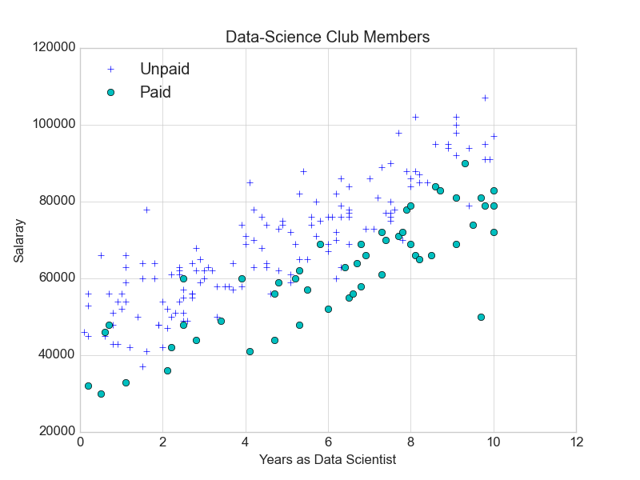

```python
from IPython.core.display import Image
Image(filename='p1.png')
```

# Problem 2

For this problem, you need to write a function **plotData2** to create a histogram plot. The histogram plot allows us discover the underlying frequency distribution of tenure data associated with the data scientists including paid and unpaid members in the club. Your plot should be similar to the figure that can be displayed below by running the code cell.

```python
def plotData2(data):
    """
    data: a list of data scientist tuples
    The function plots the the data scientists as required in the problem
    """
    pass

plotData2(data)
```

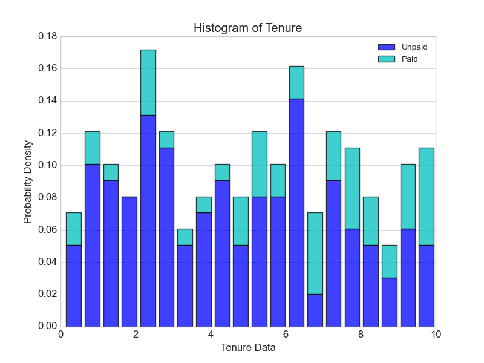

```python
from IPython.core.display import Image
Image(filename='p2.png')
```

# Problem 3

For this problem, you need to write a function **plotData3** to make a figure with two subplots. One is a bar plot, and the other is a histogram plot. The bar plot can conveniently support users to visualize how many accounts are paid and how many are unpaid. The histogram plot allows us discover the underlying frequency distribution of salary data associated with the two types of data scientists (paid and unpaid). Your plot should be similar to the figure that can be displayed below by running the code cell.

```python
def plotData3(data):
    """
    data: a list of data scientist tuples
    The function plots the the data scientists as required in the problem
    """
    pass

plotData3(data)
```

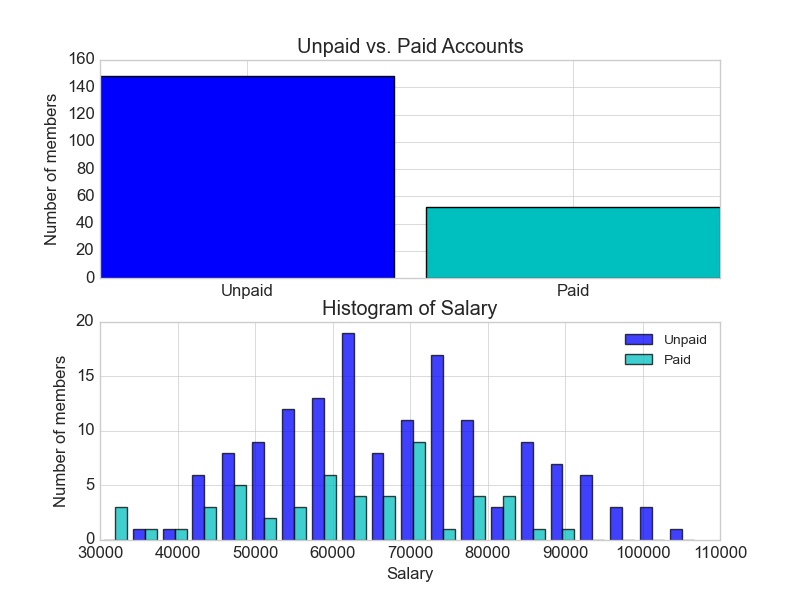

```python
from IPython.core.display import Image
Image(filename='p3.png')
```

# Problem 4 Community Data

For this problem, you need to write a function **barCommunityData** make a bar plot that shows numbers of counties in states. Your plot should be similar to the figure that can be displayed below by running the code cell that has the Image object. To approach this problem, you need to parse the data from the provided file named "county.csv". For the result plot, you need to plot the numbers of counties in Arizona, California, and Texas.

```python
def barCommunityData(filename, states):
    """
    filename: a string representing the community data file
    states: a list of strings representing the states to count the counties
    """
    pass

barCommunityData("county.csv",['Arizona', 'California', 'Texas'])
```

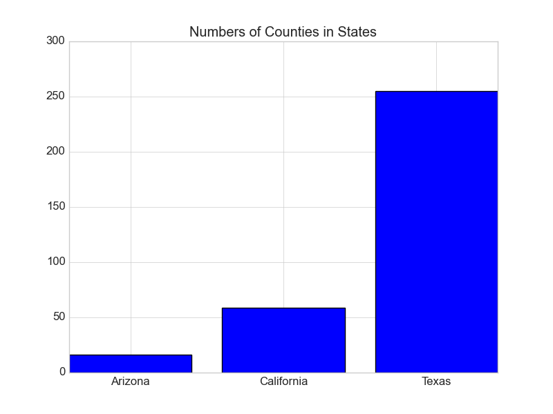

```python
from IPython.core.display import Image
Image(filename='p4.png')
```

# Turn-in

Turn in your notebook including your Python code and answers to the questions to D2L Assignments folder **Assignment 1**. That is, if a code cell's execution has generated output, the submitted file should include the output presentation.